Pular para o conteúdo principal

# Atividade Prática 13

Econometria Aplicada a Finanças  
Mestrado Profissional em Administração

Autor

Prof. Dr. Washington S. da Silva

Data de Publicação

17 de novembro de 2026

## Orientações

Nesta atividade, você estudará a aplicação do método de **diferenças-em-diferenças (DiD)** para investigar os efeitos de uma política pública sobre a cobertura de seguro-saúde nos Estados Unidos.

Utilizaremos dados reais da pesquisa *American Community Survey* (ACS) e desenvolveremos uma análise econométrica com R, desde a compreensão do problema de pesquisa até a interpretação dos resultados.

Esse arquivo apresenta as explicações e os códigos necessários para realizar a análise. Sua tarefa é estudar o conteúdo, executar os comandos na ordem apresentada, compreender os procedimentos econométricos e responder à questão proposta ao final.

O objetivo não é apenas reproduzir uma regressão, mas compreender **como o estimador DiD é construído, o que ele mede e sob quais condições admite uma interpretação causal**.

Usaremos o metapacote `tidyverse` e os pacotes `here` e `fixest`.

## O problema econômico

### A expansão do Medicaid nos Estados Unidos

O [Medicaid](https://www.medicaid.gov/) é um programa público de assistência à saúde nos Estados Unidos, destinado principalmente a pessoas e famílias de baixa renda.

A aprovação da *Affordable Care Act* (ACA), em 2010, promoveu importantes mudanças no sistema de seguro-saúde norte-americano. Entre essas mudanças estava a ampliação da elegibilidade ao Medicaid para praticamente todos os adultos com renda de até 138% da linha federal de pobreza.

Inicialmente concebida para alcançar todo o país, essa expansão tornou-se uma decisão dos governos estaduais após uma decisão da Suprema Corte dos Estados Unidos, em 2012.

A partir de 2014, alguns estados implementaram a expansão, enquanto outros decidiram não adotá-la naquele momento.

Essa diferença nas decisões estaduais oferece uma oportunidade para investigar empiricamente os efeitos da política. Informações históricas sobre sua implementação podem ser consultadas em Rudowitz et al. (2014).

Uma questão importante para a avaliação da política é determinar se os estados que expandiram o Medicaid apresentaram uma redução maior na proporção de pessoas sem seguro-saúde do que os estados que não adotaram a expansão.

A pergunta de pesquisa que orientará nossa análise é:

> **A expansão do Medicaid em 2014 reduziu a proporção de adultos sem seguro-saúde nos estados que adotaram a política, relativamente aos estados que não a adotaram?**

A pergunta envolve uma relação causal. Entretanto, não podemos responder simplesmente comparando a proporção de pessoas sem seguro-saúde entre os estados, pois eles podem apresentar diferenças econômicas, demográficas e institucionais anteriores à política.

Também não basta comparar a situação dos estados que expandiram o Medicaid antes e depois de 2014. Outras mudanças ocorridas nesse intervalo, inclusive outras disposições da própria ACA, poderiam ter afetado a cobertura de seguro-saúde.

Utilizaremos o método de **diferenças-em-diferenças** para considerar simultaneamente essas duas dimensões: as diferenças entre grupos e as mudanças ao longo do tempo.

**NotaA aplicação na literatura**

Os efeitos da *Affordable Care Act* (ACA) sobre a cobertura de seguro-saúde foram investigados em diversos estudos econométricos.

Por exemplo, Courtemanche et al. (2017) utilizaram dados da ACS e uma estratégia econométrica mais elaborada para avaliar os efeitos da reforma.

Essa atividade **não reproduz as estimativas desse artigo**. Utilizaremos uma amostra didática dos microdados da ACS para implementar a versão tradicional do DiD, com dois grupos e dois períodos.

## Os dados e o desenho de pesquisa

### A American Community Survey

A *American Community Survey* (ACS) é uma pesquisa realizada pelo *United States Census Bureau*, que coleta informações demográficas, sociais e econômicas da população norte-americana.

Os dados desta atividade são provenientes de uma amostra de microdados da ACS disponibilizada para aplicações econométricas no pacote R `stacked`, entretanto, os dados estão disponibilizados no site da disciplina, assim, não é necessário instalar esse pacote. A documentação da base original está disponível em Wing et al. (s. d.).

O conjunto distribuído pelos autores contém 69.820 observações individuais, referentes a 2008–2021, e corresponde a uma subamostra estratificada por estado e ano dos microdados da ACS, originalmente obtidos por meio do IPUMS USA (Ruggles et al. 2024).

Para esta atividade, utilizaremos um recorte específico dessa base, contendo observações dos anos de **2013 e 2015**. No arquivo fornecido, as pessoas observadas têm entre 19 e 60 anos de idade. Cada linha representa uma pessoa entrevistada em determinado ano.

Uma característica fundamental é que **não acompanhamos as mesmas pessoas ao longo do tempo**. Os indivíduos observados em 2013 não constituem necessariamente aqueles entrevistados em 2015. Portanto, trabalharemos com **cortes transversais repetidos**, e não com dados individuais em painel.

Os estados, por outro lado, são identificados nos dois períodos, permitindo comparar a evolução da cobertura de seguro-saúde entre os grupos.

### Grupos de tratamento e controle

Para construir a aplicação DiD, definimos:

- **Grupo de tratamento:** estados que adotaram a expansão do Medicaid em 2014.
- **Grupo de controle:** estados registrados na base como não adotantes da expansão até 2021.
- **Período anterior:** 2013.
- **Período posterior:** 2015.

Os estados que expandiram o programa em outros anos não participam desta análise.

O estado do Wisconsin também foi excluído: embora tenha implementado mudanças na cobertura do Medicaid em 2014, sua reforma diferiu da expansão adulta prevista pela ACA. Essa distinção é documentada pela [Kaiser Family Foundation](https://www.kff.org/affordable-care-act/state-profiles-uninsured-under-aca-wisconsin/).

A amostra final contém **8.336 observações individuais**, distribuídas por 27 unidades estaduais tratadas (26 estados e o Distrito de Columbia) e 11 estados de controle.

A variável de resultado (variável dependente) será a condição de seguro-saúde de cada pessoa:

$$Y_{ist}=
\begin{cases}
1, & \text{se a pessoa não possui seguro-saúde};\\
0, & \text{se possui seguro-saúde}.
\end{cases}$$

O subscrito $i$ identifica a pessoa, $s$ identifica o estado e $t$ identifica o ano.

Como $Y_{ist}$ é uma variável binária, sua média corresponde à **proporção de pessoas sem seguro-saúde**.

### Descrição das variáveis

**NotaArquivo de dados: `medicaid-did-2013-2015.csv`**

O arquivo contém as seguintes variáveis:

| Variável | Descrição |
| --- | --- |
| `state` | Sigla do estado norte-americano ou DC |
| `year` | Ano da observação |
| `perwt` | Peso amostral individual da ACS |
| `statefip` | Código FIPS do estado |
| `adopt_year` | Ano de adoção da expansão do Medicaid; `NA` para os controles |
| `uninsured` | Indicador de ausência de seguro-saúde (1 = sem seguro; 0 = com seguro) |
| `female` | Indicador de sexo feminino (1 = feminino; 0 = masculino) |
| `age` | Idade da pessoa, em anos |

O arquivo já contém somente os grupos e períodos selecionados para a atividade. As variáveis `female` e `age` são mantidas nos dados, mas não serão utilizadas na especificação DiD básica.

## Preparação dos dados

### Importação dos dados

O primeiro passo é importar o arquivo CSV. Como sempre, utilizaremos `here::here()` para construir o caminho relativo à raiz do projeto local da disciplina.

```r
# Localiza o CSV a partir da raiz do projeto, sem usar um caminho absoluto
caminho_csv <- here::here("data/raw/medicaid-did-2013-2015.csv")

# Importa o CSV; show_col_types = FALSE oculta a mensagem sobre os tipos das colunas
dados <- readr::read_csv(caminho_csv, show_col_types = FALSE)

# Mostra as dimensões, os nomes, os tipos e alguns valores das colunas
glimpse(dados)
```

```
Rows: 8,336
Columns: 8
$ state      <chr> "AL", "AL", "AL", "AL", "AL", "AL", "AL", "AL", "AL", "AL",…
$ year       <dbl> 2013, 2013, 2013, 2013, 2013, 2013, 2013, 2013, 2013, 2013,…
$ perwt      <dbl> 99, 8, 92, 55, 19, 112, 237, 79, 10, 276, 98, 11, 49, 68, 5…
$ statefip   <dbl> 1, 1, 1, 1, 1, 1, 1, 1, 1, 1, 1, 1, 1, 1, 1, 1, 1, 1, 1, 1,…
$ adopt_year <dbl> NA, NA, NA, NA, NA, NA, NA, NA, NA, NA, NA, NA, NA, NA, NA,…
$ uninsured  <dbl> 0, 0, 0, 1, 0, 0, 1, 1, 0, 0, 0, 0, 1, 0, 0, 0, 0, 0, 0, 0,…
$ female     <dbl> 0, 1, 0, 0, 0, 1, 0, 0, 1, 0, 1, 1, 1, 0, 1, 0, 0, 1, 0, 1,…
$ age        <dbl> 53, 21, 49, 21, 48, 23, 55, 38, 55, 43, 47, 27, 48, 53, 19,…
```

Observe que `adopt_year` apresenta valores ausentes (`NA`). Neste conjunto de dados, eles identificam os estados do grupo de controle, e não observações que precisem ser eliminadas.

### Construção dos indicadores DiD

O modelo DiD tradicional utiliza dois indicadores:

1. `tratado`: identifica se a observação pertence ao grupo de tratamento;
2. `depois`: identifica se a observação pertence ao período posterior à intervenção.

Definimos:

$$Tratado_s=
\begin{cases}
1, & \text{estado que adotou a expansão em 2014};\\
0, & \text{estado do grupo de controle}.
\end{cases}$$

e

$$Depois_t=
\begin{cases}
1, & t=2015;\\
0, & t=2013.
\end{cases}$$

O código abaixo cria as duas variáveis.

```r
# Acrescenta os dois indicadores e salva a base atualizada no objeto dados
dados <- dados |>
  mutate(
    # Atribui 0 aos controles (adopt_year ausente) e 1 aos tratados
    tratado = if_else(is.na(adopt_year), 0L, 1L),

    # Atribui 1 a 2015 (depois) e 0 a 2013 (antes)
    depois = if_else(year == 2015, 1L, 0L)
  )

# Conta pessoas em cada combinação dos indicadores; n contém a contagem
dados |>
  count(tratado, depois)
```

```
# A tibble: 4 × 3
  tratado depois     n
    <int>  <int> <int>
1       0      0  1406
2       0      1  1401
3       1      0  2778
4       1      1  2751
```

**DicaComo ler os indicadores criados com `if_else()`**

Em `if_else(condição, valor_se_verdadeira, valor_se_falsa)`, cada linha recebe um dos dois valores conforme o resultado da condição. `is.na(adopt_year)` verifica se o ano de adoção está ausente; nesta base, isso identifica o grupo de controle. Já `year == 2015` verifica se a observação pertence ao período posterior.

O sufixo `L` em `0L` e `1L` indica números inteiros. O operador `|>` passa o objeto à esquerda para a função seguinte; assim, `dados |> mutate(...)` aplica a transformação à base `dados`.

O resultado deve apresentar quatro combinações de `tratado` e `depois`, correspondentes aos dois grupos observados nos dois períodos.

Para verificar também o número de unidades estaduais em cada grupo:

```r
dados |>
  # Mantém uma linha por estado e grupo, eliminando as repetições
  distinct(state, tratado) |>
  # Conta os estados por grupo e dá um nome à coluna de contagem
  count(tratado, name = "unidades_estaduais")
```

```
# A tibble: 2 × 2
  tratado unidades_estaduais
    <int>              <int>
1       0                 11
2       1                 27
```

A unidade de observação da regressão será a pessoa. Entretanto, a **política é definida no nível estadual**, uma distinção que será importante para a inferência estatística.

## Estimando diferenças-em-diferenças

### As quatro médias

O estimador DiD tradicional combina quatro médias:

| Grupo | Antes (2013) | Depois (2015) |
| --- | --- | --- |
| Controle | $\bar Y_{C,0}$ | $\bar Y_{C,1}$ |
| Tratamento | $\bar Y_{T,0}$ | $\bar Y_{T,1}$ |

Como os dados provêm de uma pesquisa por amostragem, as pessoas entrevistadas não representam necessariamente a mesma quantidade de indivíduos na população. A variável `perwt`, disponibilizada originalmente pela ACS, contém os pesos amostrais individuais.

Nesta atividade, utilizaremos esses pesos para calcular as **médias ponderadas** nas quatro células do DiD. Posteriormente, veremos como eles também podem ser incorporados à estimação de uma regressão linear.

A média ponderada de um grupo $g$ no período $t$ é:

$$\bar Y_{g,t}^{(w)}
=
\frac{
\sum_{i\in(g,t)}w_iY_i
}{
\sum_{i\in(g,t)}w_i
},$$

em que $w_i$ é o peso da observação individual.

Em R, a função `weighted.mean()` calcula diretamente essa expressão.

```r
# Constrói uma tabela com as quatro médias ponderadas
medias <- dados |>
  # Agrupa as observações pelas combinações de grupo e período
  group_by(tratado, depois) |>
  # Resume cada combinação em uma linha
  summarise(
    # Conta as pessoas da célula, sem aplicar os pesos
    observacoes = n(),
    # Calcula a proporção sem seguro usando os pesos individuais
    proporcao = weighted.mean(uninsured, w = perwt),
    # Permite selecionar as colunas da tabela sem reter tratado como agrupador
    .groups = "drop"
  )

# Formata uma tabela para exibição, preservando o objeto medias
medias |>
  # Substitui os indicadores por rótulos de grupo e pelos anos correspondentes
  mutate(
    grupo = if_else(tratado == 1, "Tratamento", "Controle"),
    ano = if_else(depois == 1, 2015L, 2013L)
  ) |>
  # Seleciona e ordena as quatro colunas que serão exibidas
  select(grupo, ano, observacoes, proporcao) |>
  # Converte as proporções em porcentagens e arredonda a três casas decimais
  mutate(proporcao = round(100 * proporcao, 3)) |>
  # Produz a tabela com os títulos das colunas e a legenda
  knitr::kable(
    col.names = c(
      "Grupo", "Ano", "Observações", "Sem seguro (%)"
    ),
    caption = "Proporção ponderada de pessoas sem seguro-saúde."
  )
```

Proporção ponderada de pessoas sem seguro-saúde.

| Grupo | Ano | Observações | Sem seguro (%) |
| --- | --- | --- | --- |
| Controle | 2013 | 1406 | 26.130 |
| Controle | 2015 | 1401 | 21.358 |
| Tratamento | 2013 | 2778 | 19.941 |
| Tratamento | 2015 | 2751 | 10.598 |

**DicaAgrupamento e precisão das médias**

`group_by(tratado, depois)` define as quatro células do DiD, e `summarise()` calcula os resumos dentro de cada uma. O argumento `.groups = "drop"` retira os agrupamentos do resultado. Aqui ele é necessário porque, mais adiante, `select()` deve excluir `tratado`: se essa variável permanecesse como agrupadora, seria mantida automaticamente, acrescentando uma quinta coluna à tabela preparada para quatro títulos.

O segundo pipeline apenas exibe a tabela: como seu resultado não é atribuído a `medias`, esse objeto conserva as proporções com a precisão original. Os cálculos seguintes utilizam essas proporções, sem o arredondamento da apresentação.

A tabela permite observar que a proporção de pessoas sem seguro-saúde diminuiu em ambos os grupos entre 2013 e 2015.

No grupo de controle, passou de aproximadamente 26,130% para 21,358%. No grupo de tratamento, passou de aproximadamente 19,941% para 10,598%.

A redução foi maior nos estados que expandiram o Medicaid. Entretanto, **essa diferença entre as reduções ainda precisa ser calculada explicitamente**.

### O estimador DiD

O estimador de diferenças-em-diferenças é:

$$\hat\delta_{DiD}
=
(\bar Y_{T,1}-\bar Y_{T,0})
-
(\bar Y_{C,1}-\bar Y_{C,0}).$$

A primeira diferença mede a variação da proporção de pessoas sem seguro-saúde dentro de cada grupo.

A segunda diferença compara essas duas variações, descontando do grupo tratado a mudança observada no grupo de controle.

Em nossa aplicação, o cálculo é:

$$\hat\delta_{DiD}
=
(10{,}598-19{,}941)
-
(21{,}358-26{,}130)
\approx -4{,}571$$

em **pontos percentuais**.

Vamos reproduzir esse resultado diretamente com R.

```r
# Seleciona o tratamento antes da política e extrai sua proporção sem seguro
media_T_antes <- medias |>
  filter(tratado == 1, depois == 0) |>
  pull(proporcao)

# Seleciona o tratamento depois da política e extrai sua proporção sem seguro
media_T_depois <- medias |>
  filter(tratado == 1, depois == 1) |>
  pull(proporcao)

# Seleciona o controle antes da política e extrai sua proporção sem seguro
media_C_antes <- medias |>
  filter(tratado == 0, depois == 0) |>
  pull(proporcao)

# Seleciona o controle depois da política e extrai sua proporção sem seguro
media_C_depois <- medias |>
  filter(tratado == 0, depois == 1) |>
  pull(proporcao)

# Subtrai a média anterior da posterior em cada grupo (ainda em proporções)
variacao_T <- media_T_depois - media_T_antes
variacao_C <- media_C_depois - media_C_antes

# Desconta a variação do controle da variação do tratamento
did <- variacao_T - variacao_C

# Converte as variações em pontos percentuais e arredonda a três casas decimais
round(
  # Reúne os três resultados em um vetor com nomes para identificá-los na saída
  100 * c(
    "Variação no tratamento" = variacao_T,
    "Variação no controle" = variacao_C,
    "Diferenças-em-diferenças" = did
  ),
  3
)
```

```
  Variação no tratamento     Variação no controle Diferenças-em-diferenças
                  -9.343                   -4.772                   -4.571
```

**DicaDe uma linha da tabela a um valor numérico**

Em cada extração, `filter()` mantém a linha que atende simultaneamente às duas condições separadas por vírgula. Em seguida, `pull(proporcao)` retira a coluna `proporcao` da tabela e devolve seus valores como um vetor numérico. Como `medias` contém uma única linha por grupo e período, cada extração retorna apenas uma média, pronta para a subtração.

A estimativa DiD corresponde a uma **redução relativa de aproximadamente 4,57 pontos percentuais** na proporção de pessoas sem seguro-saúde nos estados que expandiram o Medicaid, em comparação com a mudança observada nos estados de controle.

Observe que esse resultado não significa que a proporção de pessoas sem seguro-saúde tenha diminuído apenas 4,57 pontos percentuais nos estados tratados. A redução efetivamente observada nesses estados foi maior.

O estimador DiD desconta a mudança que também ocorreu no grupo de controle.

### Representação gráfica

Podemos representar as quatro médias em um gráfico para visualizar a evolução dos grupos.

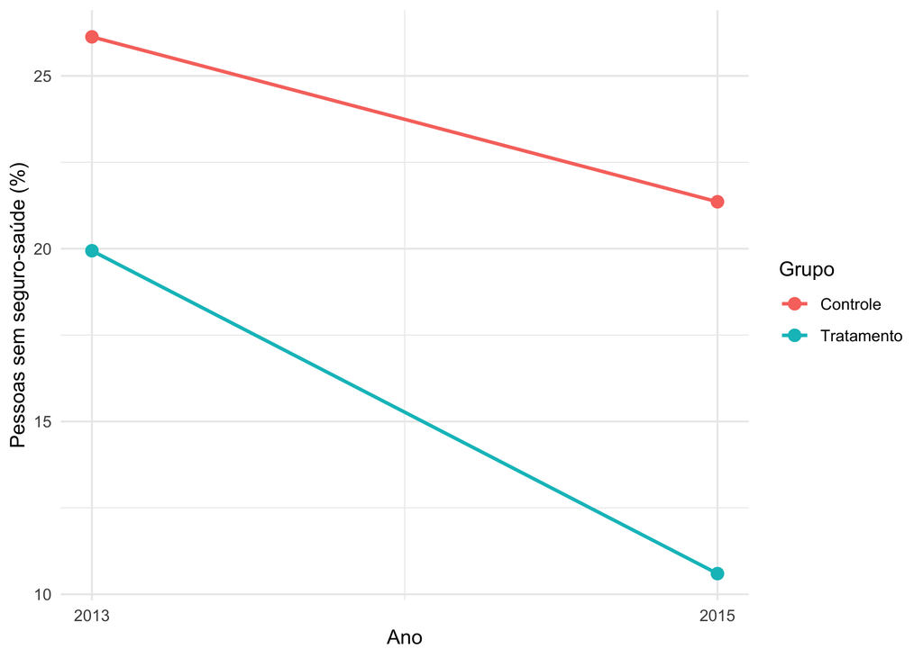

Figura 1: Proporção ponderada de pessoas sem seguro-saúde por grupo e ano.

```r
# Prepara rótulos e valores do gráfico sem modificar o objeto medias
dados_grafico <- medias |>
  mutate(
    # Recupera o ano correspondente a cada indicador de período
    ano = if_else(depois == 1, 2015L, 2013L),
    # Cria os nomes que identificarão os grupos na legenda
    grupo = if_else(
      tratado == 1,
      "Tratamento",
      "Controle"
    ),
    # Converte a proporção sem seguro para a escala percentual do eixo vertical
    percentual = 100 * proporcao
  )

# Inicia o gráfico com a tabela das médias
ggplot(
  dados_grafico,
  # Mapeia os eixos; color distingue os grupos e group define quais pontos ligar
  aes(x = ano, y = percentual, color = grupo, group = grupo)
) +
  # Liga as médias de cada grupo; linewidth controla a espessura das linhas
  geom_line(linewidth = 0.9) +
  # Destaca cada média com um ponto; size controla o tamanho dos pontos
  geom_point(size = 2.8) +
  # Exibe no eixo horizontal apenas os dois anos utilizados na análise
  scale_x_continuous(breaks = c(2013, 2015)) +
  # Define os títulos dos eixos e da legenda de cores
  labs(
    x = "Ano",
    y = "Pessoas sem seguro-saúde (%)",
    color = "Grupo"
  ) +
  # Aplica um tema com fundo claro e poucos elementos visuais
  theme_minimal()
```

A Fig. 1 mostra que a proporção sem seguro-saúde diminuiu nos dois grupos, mas a redução foi maior no grupo tratado.

Esse gráfico descreve as **mudanças observadas**. Ele não demonstra que os grupos teriam seguido tendências paralelas na ausência da expansão do Medicaid.

Essa distinção será fundamental para a interpretação causal.

## DiD como uma regressão

### Especificação econométrica

O estimador DiD também pode ser obtido a partir de uma regressão linear com dois indicadores e sua interação:

$$Y_{ist} = \beta_0 + \beta_1 Tratado_s + \beta_2 Depois_t + \delta(Tratado_s\times Depois_t) +
u_{ist}$$

Nesse modelo:

- $\beta_0$ representa a média do grupo de controle antes da intervenção;
- $\beta_1$ representa a diferença entre tratamento e controle no período anterior;
- $\beta_2$ representa a mudança temporal observada no grupo de controle;
- $\delta$ representa a **diferença das diferenças**, nosso parâmetro de interesse.

O **termo de interação** é indispensável. Sem ele, o modelo imporia a mesma mudança temporal aos dois grupos e não permitiria estimar uma diferença adicional associada ao tratamento.

Como existem quatro combinações entre os dois indicadores, a regressão com intercepto, dois indicadores e sua interação reproduz as quatro médias das células.

Consequentemente, o coeficiente da interação corresponde exatamente ao estimador DiD calculado anteriormente, desde que a regressão e o cálculo direto utilizem a mesma ponderação.

### Estimação com o pacote fixest

Utilizaremos o pacote `fixest` para estimar o modelo (Bergé et al. 2026).

A função `feols()` permite estimar uma regressão linear e especificar diretamente os pesos amostrais e a estrutura dos erros-padrão.

Como sabemos, em fórmulas para modelos com R, o operador `*` entre duas variáveis representa a inclusão de ambas (seus chamados efeitos principais) e de sua interação:

```r
tratado * depois
```

equivale a:

```r
tratado + depois + tratado:depois
```

Utilizaremos a segunda especificação, que apresenta explicitamente os dois indicadores e seu termo de interação.

Antes de estimar o modelo, precisamos compreender o **papel dos pesos amostrais na regressão linear**.

**DicaPesos amostrais e mínimos quadrados ponderados**

**O que são pesos amostrais?**

Em uma pesquisa por amostragem, nem todas as pessoas têm necessariamente a mesma probabilidade de serem incluídas na amostra. Por isso, cada pessoa entrevistada pode representar uma quantidade diferente de indivíduos da população.

Imagine dois municípios:

- No município A, com 10.000 adultos, são entrevistadas 100 pessoas. Em uma amostragem aleatória simples, cada entrevistado representa 100 adultos.
- No município B, com 5.000 adultos, são entrevistadas 200 pessoas. Cada entrevistado representa 25 adultos.

Se ignorarmos os pesos, o município B terá maior influência nos resultados simplesmente porque possui mais pessoas entrevistadas, embora sua população seja menor.

**Os pesos amostrais permitem considerar essa diferença de representação.** Em pesquisas reais, seu cálculo também pode envolver ajustes para ausência de respostas e características conhecidas da população.

Na ACS, a variável `perwt` contém o peso atribuído ao registro de cada pessoa na amostra original.

**Como os pesos entram na regressão linear?**

No método de mínimos quadrados ordinários (MQO), estimamos os coeficientes minimizando a soma dos quadrados dos resíduos:

$$\sum_{i=1}^{n}(Y_i-\widehat{Y}_i)^2.$$

No método de **mínimos quadrados ponderados (MQP)**, multiplicamos o quadrado de cada resíduo por um peso positivo $w_i$:

$$\sum_{i=1}^{n}w_i(Y_i-\widehat{Y}_i)^2.$$

Assim, observações com pesos maiores exercem maior influência sobre os coeficientes estimados.

No nosso modelo DiD, utilizamos:

```r
weights = ~perwt
```

Dessa forma, a regressão considera os mesmos pesos empregados no cálculo das quatro médias ponderadas. Como o modelo contém os indicadores de tratamento, período e sua interação, o coeficiente da interação reproduz exatamente a diferença-em-diferenças dessas médias.

**Atenção:** os pesos amostrais e os erros-padrão agrupados cumprem funções diferentes. O argumento `weights = ~perwt` modifica a estimação dos coeficientes, enquanto `vcov = ~state` determina como calculamos seus erros-padrão.

Como a base de dados usada é uma subamostra preparada da ACS, a utilização dos pesos originais não garante que os resultados representem toda a população norte-americana.

```r
# Estima o modelo DiD com pesos e erros-padrão agrupados
modelo_did <- fixest::feols(
  # Inclui os dois indicadores e a interação; o intercepto é incluído por padrão
  uninsured ~ tratado + depois + tratado:depois,
  # Indica a base na qual as variáveis da fórmula serão procuradas
  data = dados,
  # Usa perwt como peso individual; ~ indica uma variável da base
  weights = ~perwt,
  # Agrupa os erros-padrão por estado, usando todas as pessoas e ambos os anos
  vcov = ~state
)

# Exibe coeficientes, erros-padrão agrupados, estatísticas t e valores-p
summary(modelo_did)
```

```
OLS estimation, Dep. Var.: uninsured
Observations: 8,336
Weights: perwt
Standard-errors: Clustered (state)
                Estimate Std. Error  t value  Pr(>|t|)
(Intercept)     0.261303   0.011998 21.77890 < 2.2e-16 ***
tratado        -0.061889   0.022535 -2.74639 0.0092502 **
depois         -0.047724   0.016543 -2.88479 0.0064958 **
tratado:depois -0.045705   0.025560 -1.78816 0.0819425 .
---
Signif. codes:  0 '***' 0.001 '**' 0.01 '*' 0.05 '.' 0.1 ' ' 1
RMSE: 0.380982   Adj. R2: 0.021298
```

O coeficiente de interesse é `tratado:depois`. Seu valor estimado deve ser aproximadamente:

$$\hat\delta=-0{,}04571.$$

Como a variável dependente assume os valores zero e um, a estimativa está expressa em unidades de proporção.

Multiplicando por 100, obtemos:

$$100\hat\delta\approx-4{,}571
\text{ pontos percentuais}.$$

Esse resultado coincide com a dupla diferença calculada diretamente a partir das quatro médias ponderadas.

Podemos verificar a equivalência numericamente:

```r
# Retira o nome do coeficiente para compará-lo com o escalar did
coef_did <- unname(
  # Extrai os coeficientes e seleciona a interação pelo nome exato
  coef(modelo_did)["tratado:depois"]
)

# Reúne as duas estimativas em um vetor nomeado para compará-las na saída
c(
  "Dupla diferença" = did,
  "Coeficiente da regressão" = coef_did
)
```

```
         Dupla diferença Coeficiente da regressão
             -0.04570542              -0.04570542
```

```r
# Retorna TRUE se as estimativas coincidirem dentro da tolerância numérica
isTRUE(all.equal(did, coef_did, tolerance = 1e-10))
```

```
[1] TRUE
```

**DicaComparação com tolerância numérica**

Procedimentos diferentes podem produzir diferenças muito pequenas por causa da precisão numérica do computador. `all.equal()` compara os resultados admitindo uma tolerância; `1e-10` é a notação de R para $10^{-10}$, uma tolerância muito pequena.

Quando os resultados são equivalentes nessa comparação, `all.equal()` devolve `TRUE`; caso contrário, devolve uma descrição das diferenças. `isTRUE()` transforma essa resposta em um único valor lógico: `TRUE` ou `FALSE`.

A verificação deve retornar `TRUE`, confirmando que os dois procedimentos produzem a mesma estimativa, consideradas pequenas diferenças de precisão numérica.

### Inferência estatística

Até aqui, obtivemos uma estimativa pontual do coeficiente DiD. Para avaliar sua precisão, precisamos calcular os erros-padrão e realizar a inferência estatística.

Como a expansão do Medicaid foi definida no **nível estadual**, as observações de pessoas pertencentes ao mesmo estado podem apresentar erros correlacionados, inclusive entre os dois anos.

Por essa razão, utilizamos erros-padrão **agrupados por estado**, especificados em `fixest` pelo argumento:

```r
vcov = ~state
```

Esse procedimento permite considerar a correlação dos erros dentro de cada estado. A amostra contém 38 unidades estaduais, sendo 27 do grupo de tratamento e 11 do grupo de controle.

Para avaliar a significância estatística do coeficiente de interação, consideramos o teste bilateral:

$$H_0:\delta=0
\qquad\text{contra}\qquad
H_1:\delta\neq0.$$

O resumo da regressão apresenta o erro-padrão, a estatística $t$ e o valor-*p* associados à estimativa do coeficiente.

Além do teste de hipótese, é importante examinar o **intervalo de confiança**, pois ele permite avaliar a precisão da estimativa e a amplitude dos valores compatíveis com os dados e com o modelo utilizado.

Vamos calcular o intervalo de confiança de 95% para o coeficiente DiD:

```r
# Calcula o intervalo de confiança de 95% da interação
ic_did <- confint(
  # Utiliza o modelo com a estrutura de erros-padrão já especificada
  modelo_did,
  # Seleciona apenas o coeficiente da interação pelo nome
  parm = "tratado:depois",
  # Define o nível de confiança em 95%
  level = 0.95
)

# Converte os dois limites para pontos percentuais e arredonda a três casas
round(100 * ic_did, 3)
```

```
               2.5 % 97.5 %
tratado:depois -9.75  0.608
```

O intervalo de confiança complementa o teste de hipótese: enquanto o valor-*p* permite avaliar a compatibilidade dos dados com uma hipótese específica, o intervalo mostra uma faixa de valores do parâmetro que não seriam rejeitados pelo teste correspondente, ao nível de significância adotado.

Na próxima seção, utilizaremos a estimativa pontual, o teste de hipótese e o intervalo de confiança para interpretar os resultados da avaliação.

## O que podemos concluir sobre a política?

### Magnitude e precisão da estimativa

A análise de diferenças-em-diferenças produziu uma estimativa de **−4,57 pontos percentuais**. Isso significa que, entre 2013 e 2015, a proporção de adultos sem seguro-saúde diminuiu aproximadamente 4,57 pontos percentuais a mais nos estados que expandiram o Medicaid do que nos estados de controle.

Entretanto, uma estimativa pontual não informa, isoladamente, a precisão com que o parâmetro foi estimado. Para avaliar a incerteza estatística, precisamos considerar também os resultados da inferência:

- **Estimativa pontual:** −4,571 pontos percentuais;
- **Erro-padrão agrupado por estado:** 2,556 pontos percentuais;
- **Valor-*p*:** 0,0819;
- **Intervalo de confiança de 95%:** [−9,750; 0,608] pontos percentuais.

O erro-padrão é relativamente elevado em comparação com a magnitude da estimativa pontual. No teste bilateral, o valor-*p* de 0,0819 indica que **não rejeitamos a hipótese nula de coeficiente igual a zero ao nível de significância de 5%**. Isso, porém, não significa que demonstramos a inexistência de um efeito.

O intervalo de confiança oferece uma avaliação mais informativa da incerteza. Seus limites abrangem desde uma **redução de aproximadamente 9,75 pontos percentuais** até um **aumento de aproximadamente 0,61 ponto percentual** na proporção de pessoas sem seguro-saúde.

Portanto, os resultados são compatíveis tanto com reduções economicamente importantes quanto com a ausência de efeito. **A estimativa apresenta considerável incerteza estatística**, o que impede uma conclusão precisa sobre a magnitude do efeito da política.

### Interpretação causal

Além da incerteza estatística, precisamos considerar uma questão distinta: **podemos interpretar a diferença estimada como um efeito causal da expansão do Medicaid?**

Para isso, é fundamental a hipótese de **tendências paralelas**. Essa hipótese estabelece que, na ausência da expansão, a proporção de pessoas sem seguro-saúde nos estados tratados teria apresentado a mesma variação observada nos estados de controle.

Sob essa hipótese, podemos utilizar a mudança do grupo de controle para estimar o que teria ocorrido nos estados tratados caso a política não tivesse sido implementada. Esse resultado hipotético é denominado **contrafactual**:

$$\widehat{\bar Y}^{(0)}_{T,1}
=
\bar Y_{T,0}
+
(\bar Y_{C,1}-\bar Y_{C,0}).$$

Utilizando as médias ponderadas obtidas anteriormente:

$$\begin{aligned}
\widehat{\bar Y}^{(0)}_{T,1}
&\approx 19{,}94\%+(21{,}36\%-26{,}13\%)\\
&\approx 15{,}17\%.
\end{aligned}$$

A proporção efetivamente observada nos estados tratados em 2015 foi de aproximadamente **10,60%**, enquanto a proporção contrafactual estimada foi de **15,17%**. A diferença corresponde ao estimador DiD:

$$\hat\delta_{DiD}
\approx 10{,}60\%-15{,}17\%
=-4{,}57\text{ pontos percentuais}.$$

Sob a hipótese de tendências paralelas e as demais condições necessárias à identificação causal, essa diferença pode ser interpretada como uma estimativa do efeito da expansão do Medicaid sobre a proporção de adultos sem seguro-saúde nos estados tratados.

Entretanto, a hipótese de tendências paralelas não foi estabelecida nesta aplicação. Dispomos de apenas um ano anterior à expansão e, portanto, não podemos examinar as trajetórias anteriores dos grupos. Além disso, a adoção da política não foi aleatória, e outras mudanças ocorridas entre 2013 e 2015 podem ter influenciado diferentemente os estados tratados e de controle.

### Conclusão

Nossa análise encontrou uma redução relativa estimada de 4,57 pontos percentuais na proporção de adultos sem seguro-saúde nos estados que expandiram o Medicaid. **Contudo, a considerável incerteza estatística e as condições necessárias à interpretação causal não permitem estabelecer uma conclusão firme sobre o efeito da política.** Os resultados tampouco demonstram que a expansão não produziu efeitos.

Essa situação ilustra uma característica importante da pesquisa empírica: **um único estudo raramente é suficiente para estabelecer conclusões definitivas sobre os efeitos de uma política pública**. O conhecimento científico é construído pelo acúmulo de evidências de diferentes pesquisas, realizadas com dados, períodos e métodos distintos. Estudos observacionais com estratégias de identificação bem fundamentadas e, quando viáveis, experimentos cuidadosamente conduzidos podem contribuir para avaliações mais sólidas e confiáveis.

## Questão

Após estudar as explicações e executar os códigos apresentados, responda à questão a seguir. Utilize os resultados obtidos com R anteriormente para fundamentar sua resposta.

### Questão 1 — O contrafactual e a estimativa DiD

Nesta questão, utilizaremos as quatro médias ponderadas calculadas anteriormente para compreender a construção do estimador de diferenças-em-diferenças.

**Não é necessário escrever código R.** Apresente os cálculos solicitados e explique os resultados com suas palavras, utilizando os conceitos e as expressões apresentados na atividade.

**DicaExpressões para os cálculos**

Considere $T$ o grupo tratado e $C$ o grupo de controle. Os índices $0$ e $1$ representam, respectivamente, os anos de 2013 e 2015.

**Variação observada em cada grupo:**

$$\Delta\bar Y_C=\bar Y_{C,1}-\bar Y_{C,0}$$

$$\Delta\bar Y_T=\bar Y_{T,1}-\bar Y_{T,0}$$

**Resultado contrafactual dos estados tratados em 2015:**

$$\widehat{\bar Y}_{T,1}^{(0)}
=\bar Y_{T,0}+\Delta\bar Y_C$$

**Estimador de diferenças-em-diferenças:**

$$\widehat{\delta}_{DiD}
=\Delta\bar Y_T-\Delta\bar Y_C$$

Lembre-se de que o contrafactual representa o resultado que estimamos para os estados tratados **na ausência da expansão do Medicaid**, sob a hipótese de tendências paralelas.

**a)** Calcule a variação da proporção de pessoas sem seguro-saúde no grupo de controle entre 2013 e 2015.

Utilize essa variação para estimar a proporção contrafactual de pessoas sem seguro-saúde nos estados tratados em 2015.

**b)** Compare o contrafactual estimado com a proporção efetivamente observada nos estados tratados em 2015. Subtraia o valor contrafactual do valor observado e interprete a diferença obtida.

**c)** Utilize as variações observadas nos grupos tratado e de controle para calcular o estimador DiD.

Compare esse resultado com o obtido no item **b** e explique:

- Por que os dois procedimentos produzem o mesmo resultado?
- Por que não seria adequado atribuir toda a redução observada nos estados tratados à expansão do Medicaid?

## Referências

Bergé, Laurent R., Kyle Butts, e Grant McDermott. 2026. “Fast and User-Friendly Econometrics Estimations: The R Package fixest”. *arXiv preprint arXiv:2601.21749*, publicação prévia em linha. https://doi.org/10.48550/arXiv.2601.21749.

Courtemanche, Charles, James Marton, Benjamin Ukert, Aaron Yelowitz, e Daniela Zapata. 2017. “Early Impacts of the Affordable Care Act on Health Insurance Coverage in Medicaid Expansion and Non-Expansion States”. *Journal of Policy Analysis and Management* 36 (1): 178–210. https://doi.org/10.1002/pam.21961.

Rudowitz, Robin, Laura Snyder, Vernon K. Smith, Kathleen Gifford, e Eileen Ellis. 2014. *Implementing the ACA: Medicaid Spending & Enrollment Growth for FY 2014 and FY 2015*. Kaiser Family Foundation. https://www.kff.org/affordable-care-act/implementing-the-aca-medicaid-spending-enrollment-growth-for-fy-2014-and-fy-2015/.

Ruggles, Steven, Sarah Flood, Matthew Sobek, et al. 2024. *IPUMS USA: Version 15.0*. IPUMS. https://doi.org/10.18128/D010.V15.0.

Wing, Coady, Alex Hollingsworth, e Seth Freedman. s. d. *ACS Microdata Sample for Medicaid Expansion Analysis*. Acesso em 17 de novembro de 2026. https://coadywing.github.io/stacked_did_package/reference/acs_micro.html.